# Performance analysis of restaurants since the adoption of new food rating system by King County in January 2017

Sakshi Madan

14 December 2019

# Data and Agenda

- Data
  - Food Inspection data from January 2006 - November 2019
  - We had 274782 observations for food inspections. There were multiple observations for inspections which had more than one violation
  - Performance declines with higher inspection score
  - Violation Types: Critical(Red) and Non-Critical(Blue)
  - Restaurants with even one critical(red) violation in a particular year has been categorized under restaurants with critical violation
  - We have chosen 5 major cities for comparison - Seattle, Bellevue, Kent, Renton, Federal Way because they have the maximum number of restaurants in King County
- Agenda
  - Effect on median inspection score in King County
  - Effect on median inspection score in 5 major cities
  - Effect on number of restaurants with no violations, critical violations and blue violations
  - Effect on number of restaurants with no violations in 5 major cities
  - Effect on number of restaurants with critical(red) violations in 5 major cities

# Effect on median inspection score in King County

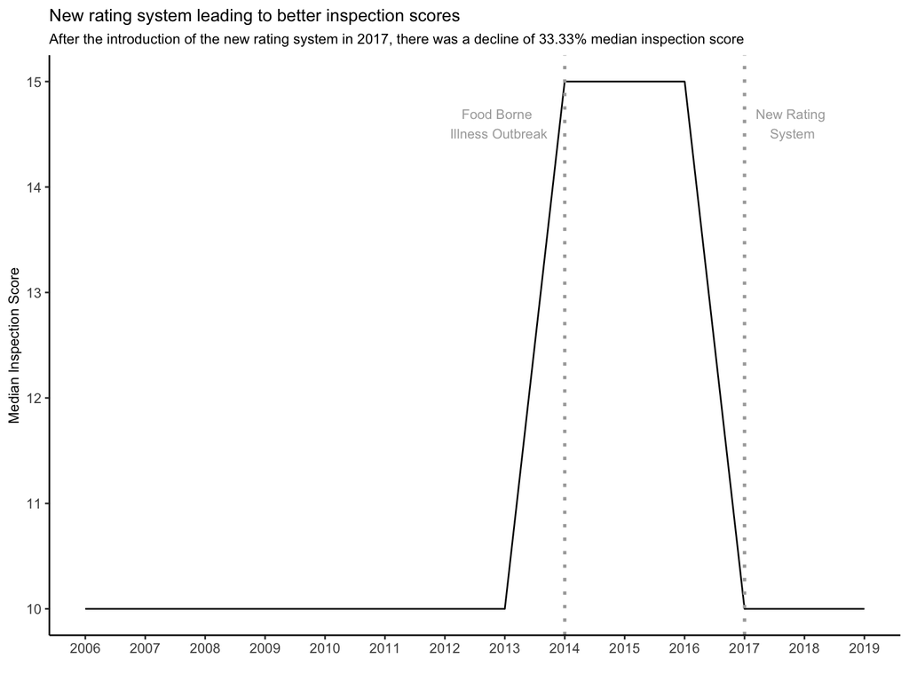

# Effect on median inspection score in 5 major cities

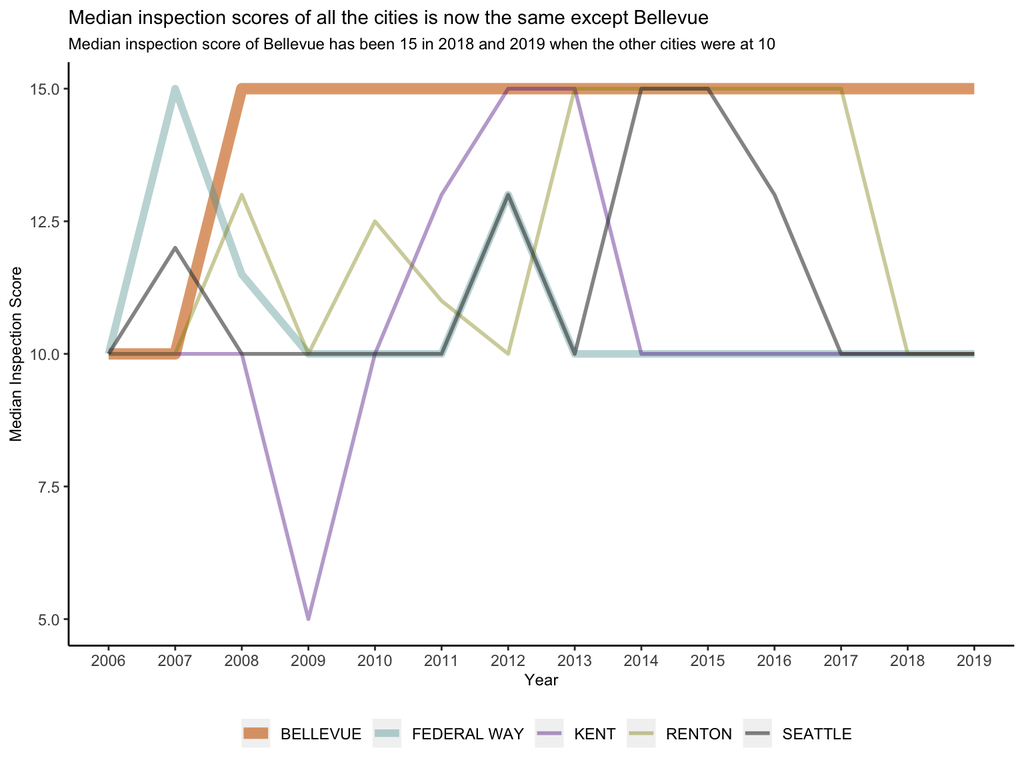

# Effect on number of restaurants with no violations, critical violations and non-critical violations

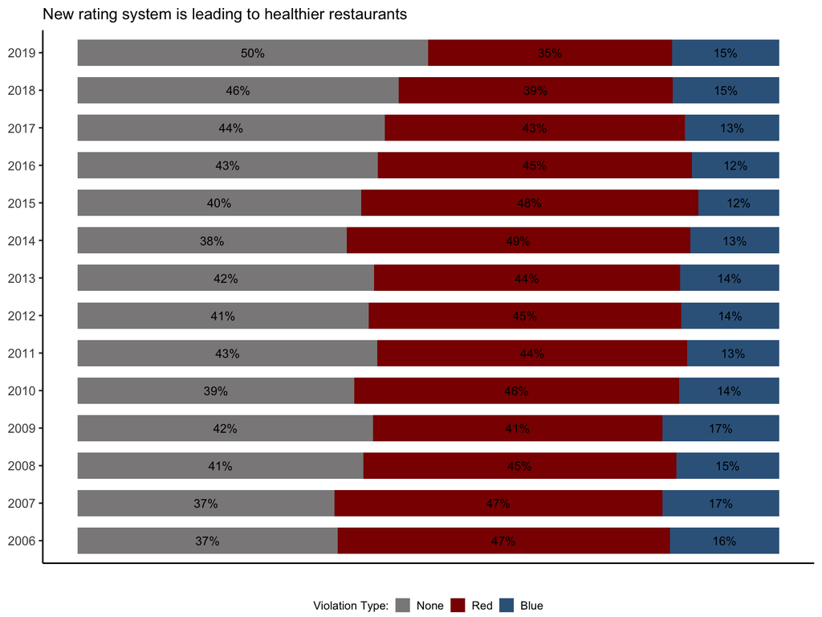

# Effect on number of restaurants with no violations in 5 major cities

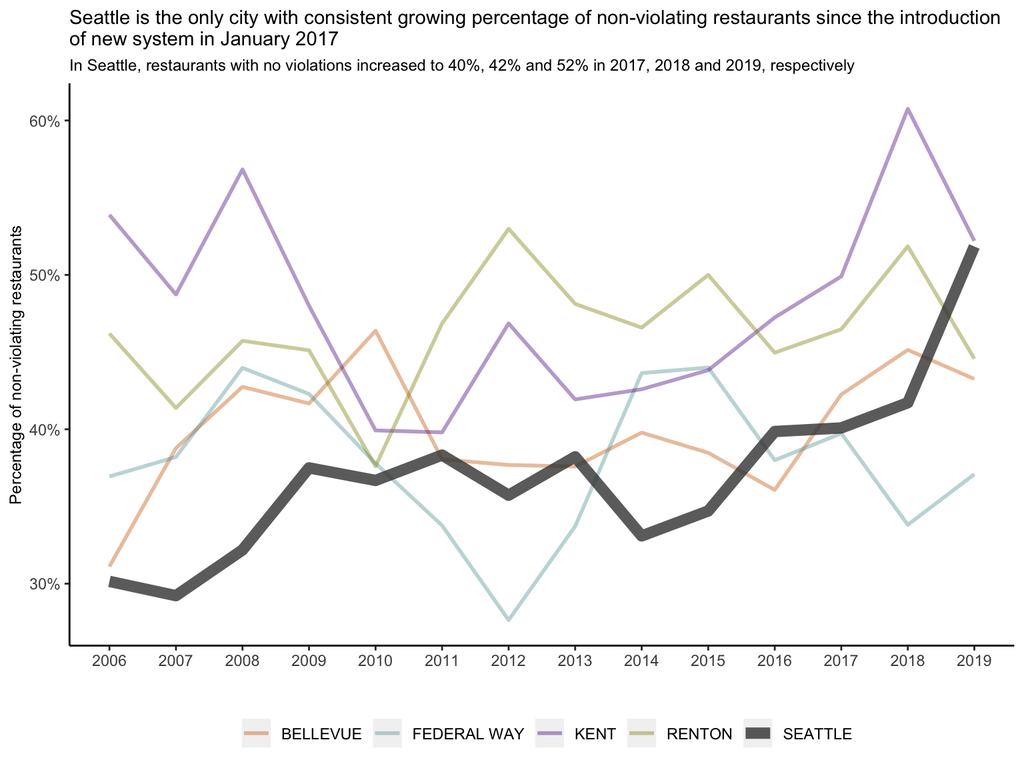

# Effect on number of restaurants with critical(red) violations in 5 major cities

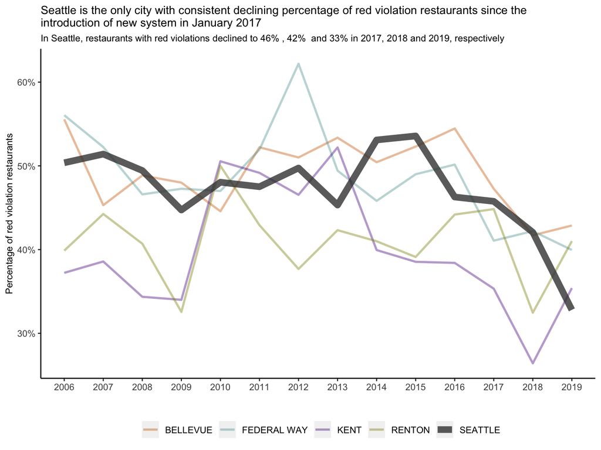

# Summary

- Performance of restaurants are improving in terms of inspection score
- Each city is responding differently to rating system
- Seattle is the most consistent one among the 5 cities
- Recommendations, questions and suggestions
- My contact information, email: smadan@seattleu.edu